# REMATCH+ Project

Jasin Cekinmez

2024-06-27

### Installs Libraries

```r
#installs libraries
library(DBI)
library(dbplyr)
library(dplyr)
library(duckdb)
library(duckplyr)
library(tidyr)
library(tidyselect)
library(tibble)
library(RSQLite)
library(stringr)
library(rlang)
library(styler)
library(sf)
```

## TibbleCreator() and its setup

#### The goal of TibbleCreator() is to create a table and csv that checks the missingness for the column provided in fullData hence the parameter column. It also can do it on a state or county basis with the region parameter. The year parameter asks whether you want on a yearly basis or overall. FIPS parameter asks whether you want it on FIPS or county. For Column you must provide one of the 103 columns in fullData that matches exactly, for the Region Parameter, you must either put `DEED SITUS STATE - STATIC` for state or `DEED SITUS COUNTY - STATIC` for county, for the YEAR parameter you must input TRUE if you want it on a yearly basis and false if not, likewise for FIPS you need to put in TRUE if you want to do it by FIPS rather than county and False if not. fullDaa, StateYearData, CountyYearData, etc are necessities for TibbleCreator() to work since they are called in it. ALSO** FIPS only works on County since it is on a county basis, the function will still work but have no difference if FIPS was set to False.

### The table below looks at the difference between SALE RECORDED DOCUMENT PAGE NUMBER & SALE RECORDED DOCUMENT NUMBER

```r
#Creates a database connection to cl.db which is the unzipped db file with deeds as the table and is a db file
con = dbConnect(duckdb(),"/projects/SHARKEY/corelogic_pu/CorelogicDeeds/2023Update/cl.db")

#Adds DC to state.abb and the goal of this is to not included territories
statenewabb = c("DC", state.abb)

#Takes the database connection and turns it into a tibble and filters out non states and DC and ones that do not exist
fullData = tbl(con, "deeds")
fullData = fullData |>
  filter(`DEED SITUS STATE - STATIC` %in% statenewabb)


#Filters data to show how many deeds each state has at least listed
StateData = fullData |>
  group_by(`DEED SITUS STATE - STATIC`) |>
  summarize(n = n())

#Filters data to show how many deeds each county has at least listed
CountyData = fullData |>
  filter(`DEED SITUS STATE - STATIC` != "NA") |>
  group_by(`DEED SITUS COUNTY - STATIC`,`DEED SITUS STATE - STATIC`) |>
  summarize(n = n())


#Creates Table filtering deed data for each state and year
StateYearData = fullData |>
  filter(`DEED SITUS STATE - STATIC` != "NA" ) |>
  group_by(substr(`SALE DERIVED DATE`,1,4),`DEED SITUS STATE - STATIC`) |>
  summarize(n=n())



#Creates Table filtering deed data for each county and year
CountyYearData = fullData |>
  filter(`DEED SITUS STATE - STATIC` != "NA" ) |>
  group_by(substr(`SALE DERIVED DATE`,1,4),
           `DEED SITUS COUNTY - STATIC`,
           `DEED SITUS STATE - STATIC`) |>
  summarize(n=n())



# does it by fips rather than county since fips may be more accurate
CountyFipsData=fullData |>
  filter(`DEED SITUS STATE - STATIC` != "NA"& `FIPS CODE`!="NA") |>
  group_by(`DEED SITUS STATE - STATIC`,`FIPS CODE`) |>
  summarize(n = n())


#creates tibble for each column and reports the missingness
#' tibbleCreator() Function
#'
#' @param column refers to the column in Corelogic
#' @param region refers to if you want the string "DEED SITUS COUNTY - STATIC" or "DEED SITUS STATE - STATIC"
#' @param year   You must give a boolean for the parameter true means you want it on a time scale false is no
#' @param fips   You must give a boolean for the parameter true means you want it using FIPS rather than county
#'
#' @return a table with county/state (and year) and the relevant column
#' @export
#'
#' @examples tibbleCreator("SALE AMOUNT","DEED SITUS STATE - STATIC",TRUE) Creates a table with the Sale Amount, with year data per state
tibbleCreator= function(column, region, year, fips) {

#turns column into variable rather than string
column = as.name(column)

#Checks if we want to filter by state data
if(region == "DEED SITUS STATE - STATIC"){

#Filters solely by state not year
  if(!year){

#creates the column name
colu = paste0(toString(column)," PRESENT")

#filters entire data by state and disregards NA values and gives the total number of deeds per state satisfying the condition
region = as.name(region)

#Filters data to only count data that has the relevant column filled checks if you want fips code

data = fullData |>
          group_by(region) |>
          filter(column !="NA") |>
         summarize(!!colu := n())
#the above table is now being appended to the right by the total # of deeds per state

region = toString(region)

#Combines tables
data = left_join(data, StateData, by=region)

#Changes column names
data = data |>
  rename("Total Deeds" = `n`)


#Now gives the missingness
data = data |>
  mutate("% missing"= round((100* (1-(!!sym(colu))/(`Total Deeds`))), digits=2))

#Arranges in descending order
data = data |>
  arrange(desc(`DEED SITUS STATE - STATIC`))


#CREATES CSV File
column = toString(column)
csvtitle=paste0("/home/jc9154/cl-validation/Output/",column,region,".csv")
write.csv(data,csvtitle)
return(data)}

#Filters by state and year
  else{

colu = paste0(toString(column)," PRESENT")

#filters entire data by state and disregards NA values and gives the total number of deeds per state satisfying the condition
region = as.name(region)

data = fullData |>
  filter(column!="NA") |>
  filter(`DEED SITUS STATE - STATIC` != "NA") |>
  group_by(substr(`SALE DERIVED DATE`, 1, 4),`DEED SITUS STATE - STATIC`) |>
  summarize(!!colu := n())

region = toString(region)

data = left_join(data, StateYearData, by=c("substr(`SALE DERIVED DATE`, 1, 4)","DEED SITUS STATE - STATIC"))

data = data |>
  rename("Total Deeds" = `n`)

data = data |>
  rename(`SALE DERIVED YEAR` = `substr(\`SALE DERIVED DATE\`, 1, 4)`)

data = data |>
  mutate("% missing"= round((100* (1-(!!sym(colu))/(`Total Deeds`))), digits=2))

#Now gives the missingness
data = data |>
  arrange(desc(`DEED SITUS STATE - STATIC`),desc(`SALE DERIVED YEAR`))

#CREATES CSV File
column=toString(column)
csvtitle=paste0("/home/jc9154/cl-validation/Output/",column,region,"YEAR.csv")
write.csv(data,csvtitle)


return(data) }}

#Filters by county data
else{

  if(!year){

region = as.name(region)

colu = paste0(toString(column)," PRESENT")

if(!fips){
data = fullData |>
  filter(column != "NA") |>
  filter(`DEED SITUS STATE - STATIC` != "NA" ) |>
  group_by(region,`DEED SITUS STATE - STATIC`)  |>
  summarize(!!colu := n())

region = toString(region)

data = data|>
  left_join(CountyData, data, by=c(region,"DEED SITUS STATE - STATIC"))


data = data |>
  rename("Total Deeds" = `n`)


data = data |>
  mutate("% missing"= round((100* (1-(!!sym(colu))/(`Total Deeds`))), digits=2))

#Now gives the missingness
data = data |>
  arrange(desc(`DEED SITUS STATE - STATIC`),desc(`DEED SITUS COUNTY - STATIC`))

#CREATES CSV File
column=toString(column)
csvtitle=paste0("/home/jc9154/cl-validation/Output/",column,region,".csv")
write.csv(data,csvtitle)


return(data)
}
else {
data = fullData |>
  filter(column != "NA"& `FIPS CODE`!="NA") |>
  filter(`DEED SITUS STATE - STATIC` != "NA" ) |>
  group_by(`DEED SITUS STATE - STATIC`,`FIPS CODE`) |>
  summarize(!!colu := n())



data = data|>
  left_join(CountyFipsData, data, by=c("DEED SITUS STATE - STATIC","FIPS CODE"))


data = data |>
  rename("Total Deeds" = `n`)


data = data |>
  mutate("% missing"= round((100* (1-(!!sym(colu))/(`Total Deeds`))), digits=2))

#Now gives the missingness
data = data |>
  arrange(desc(`DEED SITUS STATE - STATIC`))

#CREATES CSV File
column=toString(column)
csvtitle=paste0("/home/jc9154/cl-validation/Output/",column,region,".csv")
write.csv(data,csvtitle)


return(data)
}}

#Filters by county and year
  else{

colu = paste0(toString(column)," PRESENT")
#filters entire data by state and disregards NA values and gives the total number of deeds per state satisfying the condition

region = as.name(region)

data = fullData |>
  filter(column!="NA") |>
  filter(`DEED SITUS STATE - STATIC` != "NA") |>
  group_by(substr(`SALE DERIVED DATE`, 1, 4),
           `DEED SITUS COUNTY - STATIC`,
           `DEED SITUS STATE - STATIC`) |>
  summarize(!!colu := n())


region = toString(region)

data = left_join(data,CountyYearData, by=c("substr(`SALE DERIVED DATE`, 1, 4)","DEED SITUS COUNTY - STATIC","DEED SITUS STATE - STATIC"))

data = data |>
  rename("Total Deeds" = `n`)

data = data |>
  rename(`SALE DERIVED YEAR` = `substr(\`SALE DERIVED DATE\`, 1, 4)`)

data = data |>
  mutate("% missing"= round((100* (1-(!!sym(colu))/(`Total Deeds`))), digits=2))


data = data |>
  arrange(desc(`DEED SITUS STATE - STATIC`),
          desc(`DEED SITUS COUNTY - STATIC`) ,
          desc(`SALE DERIVED YEAR`))

#CREATES CSV File
column=toString(column)
csvtitle=paste0("/home/jc9154/cl-validation/Output/",column,region,"YEAR.csv")
write.csv(data,csvtitle)


return(data)


}}}

#CREATES CSV's in Output Folder
#Well now tibbleCreator needs a fourth parameter

#data=tibbleCreator("ACTUAL YEAR BUILT - STATIC","DEED SITUS STATE - STATIC",FALSE)
#data=tibbleCreator("BUYER OCCUPANCY CODE","DEED SITUS STATE - STATIC",FALSE)
#data=tibbleCreator("CLIP","DEED SITUS STATE - STATIC",FALSE)
#data=tibbleCreator("DEED CATEGORY TYPE CODE","DEED SITUS STATE - STATIC",FALSE)
#data=tibbleCreator("SALE DOCUMENT TYPE  CODE","DEED SITUS STATE - STATIC",FALSE)
#data=tibbleCreator("FIPS CODE","DEED SITUS STATE - STATIC",FALSE)
#data=tibbleCreator("PRIMARY CATEGORY CODE","DEED SITUS STATE - STATIC",FALSE)
#data=tibbleCreator("PROPERTY INDICATOR CODE - STATIC","DEED SITUS STATE - STATIC",FALSE)
#data=tibbleCreator("SALE AMOUNT","DEED SITUS STATE - STATIC",FALSE)
#data=tibbleCreator("SALE DERIVED DATE","DEED SITUS STATE - STATIC",FALSE)
#data=tibbleCreator("SALE DERIVED RECORDING DATE","DEED SITUS STATE - STATIC",FALSE)
#data=tibbleCreator("DEED SITUS CITY - STATIC","DEED SITUS STATE - STATIC",FALSE)
#data=tibbleCreator("DEED SITUS ZIP CODE - STATIC","DEED SITUS STATE - STATIC",FALSE)
#data=tibbleCreator("EFFECTIVE YEAR BUILT - STATIC","DEED SITUS STATE - STATIC",FALSE)
#data=tibbleCreator("FIPS CODE","DEED SITUS COUNTY - STATIC",FALSE)
print(tibbleCreator("SALE RECORDED DOCUMENT NUMBER","DEED SITUS STATE - STATIC",FALSE,FALSE))
```

```
## # Source:     SQL [?? x 4]
## # Database:   DuckDB v0.10.2 [jc9154@Linux 4.18.0-553.5.1.el8_10.x86_64:R 4.4.0//projects/SHARKEY/corelogic_pu/CorelogicDeeds/2023Update/cl.db]
## # Ordered by: desc(`DEED SITUS STATE - STATIC`)
##    `DEED SITUS STATE - STATIC` SALE RECORDED DOCUMEN…¹ `Total Deeds` `% missing`
##    <chr>                                         <dbl>         <dbl>       <dbl>
##  1 WY                                           416417        484377       14.0
##  2 WV                                           257651       2938992       91.2
##  3 WI                                          5251278       5552454        5.42
##  4 WA                                          8708846       9476857        8.1
##  5 VT                                           613056        904631       32.2
##  6 VA                                          4538476       9003259       49.6
##  7 UT                                          4103752       4530223        9.41
##  8 TX                                         19457779      29105600       33.2
##  9 TN                                          7693549      11165153       31.1
## 10 SD                                            78826        405515       80.6
## # ℹ more rows
## # ℹ abbreviated name: ¹`SALE RECORDED DOCUMENT NUMBER PRESENT`
```

```r
print(tibbleCreator("SALE RECORDED DOCUMENT PAGE NUMBER","DEED SITUS STATE - STATIC",FALSE,FALSE))
```

```
## # Source:     SQL [?? x 4]
## # Database:   DuckDB v0.10.2 [jc9154@Linux 4.18.0-553.5.1.el8_10.x86_64:R 4.4.0//projects/SHARKEY/corelogic_pu/CorelogicDeeds/2023Update/cl.db]
## # Ordered by: desc(`DEED SITUS STATE - STATIC`)
##    `DEED SITUS STATE - STATIC` SALE RECORDED DOCUMEN…¹ `Total Deeds` `% missing`
##    <chr>                                         <dbl>         <dbl>       <dbl>
##  1 WY                                           276992        484377       42.8
##  2 WV                                          2725847       2938992        7.25
##  3 WI                                           835265       5552454       85.0
##  4 WA                                           483537       9476857       94.9
##  5 VT                                           575188        904631       36.4
##  6 VA                                          5099207       9003259       43.4
##  7 UT                                          2554201       4530223       43.6
##  8 TX                                         12691802      29105600       56.4
##  9 TN                                          8292327      11165153       25.7
## 10 SD                                           282748        405515       30.3
## # ℹ more rows
## # ℹ abbreviated name: ¹`SALE RECORDED DOCUMENT PAGE NUMBER PRESENT`
```

```r
#disconnects in order to avoid garbage collecting
dbDisconnect(con)
```

### Alongside some other visualization, this code made me realize that the Corelogic Dataset has not updated county names, as in 1997 Dade County became Miami Dade County, but this dataset still uses Dade County even after 1997.

```r
con = dbConnect(duckdb(),"/projects/SHARKEY/corelogic_pu/CorelogicDeeds/2023Update/cl.db")

fullData = tbl(con, "deeds")
fullData = fullData |>
  filter(`DEED SITUS STATE - STATIC` %in% statenewabb)

Miami=fullData |> filter(`DEED SITUS CITY - STATIC`=="MIAMI") |> filter(as.numeric(`ACTUAL YEAR BUILT - STATIC`)>1997) |> select(`DEED SITUS COUNTY - STATIC`)
print(Miami)
```

```
## # Source:   SQL [?? x 1]
## # Database: DuckDB v0.10.2 [jc9154@Linux 4.18.0-553.5.1.el8_10.x86_64:R 4.4.0//projects/SHARKEY/corelogic_pu/CorelogicDeeds/2023Update/cl.db]
##    `DEED SITUS COUNTY - STATIC`
##    <chr>
##  1 DADE
##  2 DADE
##  3 DADE
##  4 DADE
##  5 DADE
##  6 DADE
##  7 DADE
##  8 DADE
##  9 DADE
## 10 DADE
## # ℹ more rows
```

```r
dbDisconnect(con)
```

### This code snippet shows that there are errors in the reporting of States whether numerical or ones that simply just don’t exist

```r
con = dbConnect(duckdb(),"/projects/SHARKEY/corelogic_pu/CorelogicDeeds/2023Update/cl.db")

fullData = tbl(con, "deeds")
#Takes out lowercase state abbreviations made me realize there are quite a bit of different non state abbreviations
#,yet there are still many typo caps
caps= fullData |> filter(str_detect(`DEED SITUS STATE - STATIC`,"[A-Z][A-Z]")||is.na(`DEED SITUS STATE - STATIC`)) |>        group_by(`DEED SITUS STATE - STATIC`) |>
  summarize(n = n())
print(caps)
```

```
## # Source:   SQL [?? x 2]
## # Database: DuckDB v0.10.2 [jc9154@Linux 4.18.0-553.5.1.el8_10.x86_64:R 4.4.0//projects/SHARKEY/corelogic_pu/CorelogicDeeds/2023Update/cl.db]
##    `DEED SITUS STATE - STATIC`        n
##    <chr>                          <dbl>
##  1 KS                           3208075
##  2 MN                           5618529
##  3 NC                          13197602
##  4 OK                           6444927
##  5 ID                           2251551
##  6 OG                                 1
##  7 MD                           7929630
##  8 AZ                          15692800
##  9 CO                          10552834
## 10 PR                                67
## # ℹ more rows
```

```r
dbDisconnect(con)
```

### Deals with FMV Sales (Talk with Angela about next steps)

```r
con = dbConnect(duckdb(),"/projects/SHARKEY/corelogic_pu/CorelogicDeeds/2023Update/cl.db")

fullData = tbl(con, "deeds")
fullData = fullData |>
  filter(`DEED SITUS STATE - STATIC` %in% statenewabb)


#displays number of NON FMV data
FMVData= fullData |> filter(`PRIMARY CATEGORY CODE`=="B"||`PRIMARY CATEGORY CODE`=="C"||`FORECLOSURE REO SALE INDICATOR`=="1"||`SALE TYPE CODE`=="L"||`INTERFAMILY RELATED INDICATOR`=="1"||`SHORT SALE INDICATOR`=="1")|>
  summarize(n=n())
#print(FMVData)

#Currently FMV DATA took a while to realize that the reason sale type code was causing issues was that it had NA Values
#
FMVData = fullData |>
  filter(`PRIMARY CATEGORY CODE`!="B"&`PRIMARY CATEGORY CODE`!="C"&`FORECLOSURE REO SALE INDICATOR`!="1"& `INTERFAMILY RELATED INDICATOR`!="1" & `SHORT SALE INDICATOR`!="1") |>
  filter(`SALE TYPE CODE`!="L"||is.na(`SALE TYPE CODE`))
#print(FMVData)


#THIS SECTION looks at each group to see the most common type of each and which codes exist
Primtype= fullData |> group_by(`PRIMARY CATEGORY CODE`) |>
summarize(n=n())
#print(Primtype)

Cattype= fullData |> group_by(`DEED CATEGORY TYPE CODE`) |> summarize(n=n())
#print(Cattype)

SaleType= fullData |> group_by(`SALE TYPE CODE`) |> summarize(n=n())
#print(SaleType)

Saledoc = fullData |> group_by(`SALE DOCUMENT TYPE  CODE`) |> summarize(n=n())
#print(Saledoc)

family= fullData |> group_by(`INTERFAMILY RELATED INDICATOR`) |> summarize(n=n())
#print(family)

short= fullData |> group_by(`SHORT SALE INDICATOR`) |> summarize(n=n())
#print(short)

foreclosure = fullData |> group_by(`FORECLOSURE REO SALE INDICATOR`) |> summarize(n=n())
#print(foreclosure)

dbDisconnect(con)
```

#### Quantile Data Info

```r
con = dbConnect(duckdb(),"/projects/SHARKEY/corelogic_pu/CorelogicDeeds/2023Update/cl.db")

fullData = tbl(con, "deeds")
fullData = fullData |>
  filter(`DEED SITUS STATE - STATIC` %in% statenewabb)

##### THIS FINDS THE MEDIAN SALE DERIVED DATE YEAR FOR EACH STATE
QuartileData=fullData |> filter(`DEED SITUS STATE - STATIC`!="NA") |> select(`SALE DERIVED DATE`,`DEED SITUS STATE - STATIC`) |> mutate("SALE DERIVED YEAR"=substr(`SALE DERIVED DATE`,1,4)) |> group_by(`DEED SITUS STATE - STATIC`) |> select(-`SALE DERIVED DATE`) |> summarize(Median = median(as.numeric(`SALE DERIVED YEAR`),na.rm = TRUE ))


#finds the 2.5% quantile for each state
QuantileStateData = fullData |>
  filter(`DEED SITUS STATE - STATIC`!="NA") |>
  select(`SALE DERIVED DATE`,`DEED SITUS STATE - STATIC`) |>
  mutate("SALE DERIVED YEAR"=substr(`SALE DERIVED DATE`,1,4)) |>
  group_by(`DEED SITUS STATE - STATIC`) |>
  summarize(quantile2.5Year = quantile(as.numeric(`SALE DERIVED YEAR`), na.rm = T, probs = c(.025)))

csvtitle=paste0("/home/jc9154/cl-validation/Output/","QuantileStateData")
#write.csv(QuantileStateData,csvtitle)

QuantileArmsStateData= fullData |> filter(`DEED SITUS STATE - STATIC`!="NA"&`PRIMARY CATEGORY CODE`=="A") |>
  select(`SALE DERIVED DATE`,`DEED SITUS STATE - STATIC`) |>
  mutate("SALE DERIVED YEAR"=substr(`SALE DERIVED DATE`,1,4)) |>
  group_by(`DEED SITUS STATE - STATIC`) |>
  summarize(quantile2.5Year = quantile(as.numeric(`SALE DERIVED YEAR`), na.rm = T, probs = c(.025)))


csvtitle=paste0("/home/jc9154/cl-validation/Output/","QuantileArmsStateData")
#write.csv(QuantileArmsStateData,csvtitle)

#finds the 2.5% Quantile for each county
QuantileCountyData = fullData |>
  filter(`DEED SITUS STATE - STATIC`!="NA") |>
  select(`SALE DERIVED DATE`,
         `DEED SITUS COUNTY - STATIC` ,
         `DEED SITUS STATE - STATIC`) |>
  mutate("SALE DERIVED YEAR"=substr(`SALE DERIVED DATE`,1,4)) |>
  group_by(`DEED SITUS COUNTY - STATIC`,`DEED SITUS STATE - STATIC`) |>
  summarize(quantile2.5Year = quantile(as.numeric(`SALE DERIVED YEAR`), na.rm = T, probs = c(.025)))


#UNCOMMENT WHEN NECESSARY
QuantileArmsCountyData=fullData |>
  filter(`DEED SITUS STATE - STATIC`!="NA"&`PRIMARY CATEGORY CODE`=="A") |>
 select(`SALE DERIVED DATE`,
         `DEED SITUS COUNTY - STATIC` ,
         `DEED SITUS STATE - STATIC`) |>
  mutate("SALE DERIVED YEAR"=substr(`SALE DERIVED DATE`,1,4)) |>
 filter(as.numeric(`SALE DERIVED YEAR`)>1970) |>
  group_by(`DEED SITUS COUNTY - STATIC`,`DEED SITUS STATE - STATIC`) |>
  summarize(quantile2.5Year = quantile(as.numeric(`SALE DERIVED YEAR`), na.rm = T, probs = c(.025)))
csvtitle=paste0("/home/jc9154/cl-validation/Output/","QuantileArmsCountyData")
#write.csv(QuantileArmsCountyData,csvtitle)

dbDisconnect(con)
```

### Just to illustrate some errors in the Deeds Data we can see how mistaken the data is in San Diego

```r
con = dbConnect(duckdb(),"/projects/SHARKEY/corelogic_pu/CorelogicDeeds/2023Update/cl.db")

fullData = tbl(con, "deeds")
fullData = fullData |>
  filter(`DEED SITUS STATE - STATIC` %in% statenewabb)

# this code helped me realize mistakes present in the data
#filters data to show how many deeds each state has at least listed
CountyData= fullData|>filter(`DEED SITUS STATE - STATIC`!="NA")|> filter(`DEED SITUS COUNTY - STATIC`=="SAN DIEGO" & `DEED SITUS STATE - STATIC` != "CA") |> select(`DEED SITUS CITY - STATIC`,`DEED SITUS COUNTY - STATIC`,`DEED SITUS STATE - STATIC`,`FIPS CODE`)
print(CountyData)
```

```
## # Source:   SQL [?? x 4]
## # Database: DuckDB v0.10.2 [jc9154@Linux 4.18.0-553.5.1.el8_10.x86_64:R 4.4.0//projects/SHARKEY/corelogic_pu/CorelogicDeeds/2023Update/cl.db]
##    `DEED SITUS CITY - STATIC` DEED SITUS COUNTY - STATI…¹ DEED SITUS STATE - S…²
##    <chr>                      <chr>                       <chr>
##  1 TEMPE                      SAN DIEGO                   AZ
##  2 SATELLITE BEACH            SAN DIEGO                   FL
##  3 ALEXANDRIA                 SAN DIEGO                   VA
##  4 OREM                       SAN DIEGO                   UT
##  5 HENDERSON                  SAN DIEGO                   NV
##  6 LAS VEGAS                  SAN DIEGO                   NV
##  7 DENVER                     SAN DIEGO                   CO
##  8 YUMA                       SAN DIEGO                   AZ
##  9 PLANO                      SAN DIEGO                   TX
## 10 LISLE                      SAN DIEGO                   NY
## # ℹ more rows
## # ℹ abbreviated names: ¹`DEED SITUS COUNTY - STATIC`,
## #   ²`DEED SITUS STATE - STATIC`
## # ℹ 1 more variable: `FIPS CODE` <chr>
```

```r
dbDisconnect(con)
```

### Takes a closer look at Arms Length Sales

```r
con = dbConnect(duckdb(),"/projects/SHARKEY/corelogic_pu/CorelogicDeeds/2023Update/cl.db")

fullData = tbl(con, "deeds")
fullData = fullData |>
  filter(`DEED SITUS STATE - STATIC` %in% statenewabb)


CountyFipsTypeAData=fullData |>
 filter(`DEED SITUS STATE - STATIC` != "NA"& `FIPS CODE`!="NA"&`PRIMARY CATEGORY CODE`=="A") |>
  group_by(`DEED SITUS STATE - STATIC`,`FIPS CODE`) |>
  summarize(n = n())
#print(CountyFipsTypeAData)

data = fullData |>
  filter(`FIPS CODE`!="NA"&`PRIMARY CATEGORY CODE`=="A"&`SALE AMOUNT`!="NA") |>
 filter(`DEED SITUS STATE - STATIC` != "NA" ) |>
 group_by(`DEED SITUS STATE - STATIC`,`FIPS CODE`) |>
  summarize("Sale Amount Present" := n())



data = data|>
  left_join(CountyFipsTypeAData, data, by=c("DEED SITUS STATE - STATIC","FIPS CODE"))


data = data |>
  rename("Total Deeds" = `n`)


data = data |>
  mutate("% missing"= round((100* (1-(`Sale Amount Present`)/(`Total Deeds`))), digits=2))

#Now gives the missingness
data = data |>
 arrange(desc(`DEED SITUS STATE - STATIC`))

#print(data)

#CREATES CSV File
#csvtitle=paste0("/home/jc9154/cl-validation/Output/","SaleAmountTypeA",".csv")
#write.csv(data,csvtitle)

dbDisconnect(con)
```

### Looks at when the Fips is missing and its effect on the missingness of the Street, Zipcode, and City

```r
con = dbConnect(duckdb(),"/projects/SHARKEY/corelogic_pu/CorelogicDeeds/2023Update/cl.db")

fullData = tbl(con, "deeds")
fullData = fullData |>
  filter(`DEED SITUS STATE - STATIC` %in% statenewabb)


missingFips=fullData |> filter(is.na(`FIPS CODE`)) |> mutate("CITY PRESENT"=is.na(`DEED SITUS CITY - STATIC`), .before = CLIP) |> mutate("ZIPCODE PRESENT"=is.na(`DEED SITUS ZIP CODE - STATIC`), .before = CLIP) |> mutate("County Present"=is.na(`DEED SITUS COUNTY - STATIC`), .before = CLIP) |> mutate("State Present"= is.na(`DEED SITUS STATE - STATIC`), .before = CLIP) |> mutate("Street Present"=is.na(`DEED SITUS STREET NAME - STATIC`), .before = CLIP) |> filter(`Street Present`==TRUE & `CITY PRESENT`==TRUE & `ZIPCODE PRESENT` == TRUE)


#I got the two tables in the doc by simply adding or removing ! from Street NOT Present
missingFipsProp=fullData |> filter(is.na(`FIPS CODE`)) |> mutate("CITY NOT PRESENT"=is.na(`DEED SITUS CITY - STATIC`), .before = CLIP) |> mutate("ZIPCODE NOT PRESENT"=is.na(`DEED SITUS ZIP CODE - STATIC`), .before = CLIP) |> mutate("Street NOT Present"=is.na(`DEED SITUS STREET NAME - STATIC`), .before = CLIP) |> filter(!(`Street NOT Present`)) |> group_by(`Street NOT Present`,`CITY NOT PRESENT`,`ZIPCODE NOT PRESENT`) |> summarise(n=(n()), .groups = "drop") |> mutate(prop=round((n/sum(n)),digits = 3))

missingFips = missingFips |> filter(is.na(`APN SEQUENCE NUMBER`)==FALSE) |> summarise(n=n())


dbDisconnect(con)
```

```r
con = dbConnect(duckdb(),"/projects/SHARKEY/corelogic_pu/CorelogicDeeds/2023Update/cl.db")

fullData = tbl(con, "deeds")
fullData = fullData |>
  filter(`DEED SITUS STATE - STATIC` %in% statenewabb)

kodzebue=fullData |> filter(`DEED SITUS CITY - STATIC`=="KOTZEBUE") |> select(`FIPS CODE`,`DEED SITUS CITY - STATIC`,`DEED SITUS COUNTY - STATIC`)
print(kodzebue)
```

```
## # Source:   SQL [2 x 3]
## # Database: DuckDB v0.10.2 [jc9154@Linux 4.18.0-553.5.1.el8_10.x86_64:R 4.4.0//projects/SHARKEY/corelogic_pu/CorelogicDeeds/2023Update/cl.db]
##   `FIPS CODE` `DEED SITUS CITY - STATIC` `DEED SITUS COUNTY - STATIC`
##   <chr>       <chr>                      <chr>
## 1 <NA>        KOTZEBUE                   KENAI
## 2 35053       KOTZEBUE                   SOCORRO
```

```r
dbDisconnect(con)
```

## LollipopCreator()

#### This function creates a Lollipop graph so for the parameter column you give a column in the database which is the parameter column and then give the column number for which you want to start at and end is the column you want to end at. So the LollipopCreator() makes a lollipop graph comparing the missigness for the specific columns you chose given when the column paramter you gave is present and not present.I also added list parameter so you can add a list with specific values rather than having to choose a specific value. Also the type parameter adds a filter to the specific column parameter in order to have more specific lollipop graphs. More parameters added to give more specific lollipop graphs.

### LollipopCreator() has grown quite large with many more parameters, but depending on the needs of the research I may add more conditionals since right now I don’t have all possible cases since I haven’t had the need for them

##### Important Realization columns 3 and 4 are equal in presence APN Sequence Number

```r
library(ggplot2)
con = dbConnect(duckdb(),"/projects/SHARKEY/corelogic_pu/CorelogicDeeds/2023Update/cl.db")




statenewabb = c("DC", state.abb)
statenewabb=sort(statenewabb,TRUE)

fullData = tbl(con, "deeds")
fullData = fullData |>
  filter(`DEED SITUS STATE - STATIC` %in% statenewabb)

x=length(statenewabb)

#' Title
#'
#' @param column string given x gives % complete
#' @param start numeric where in fullData you want to begin put "" if you want to use list instead
#' @param end numeric where in fullData you want to end  put "" if you want to use list instead
#' @param list type list put in a list with the exact column names from full Data "" if you want to use top 2 instead
#' @param type string if you want to filter column put "" if you don't want to filter
#' @param filter string if you want to filter a column in start-end or list put "" if you don't want to filter
#' @param na    boolean set TRUE if you want to include NA's else FALSE to exclude NA's
#' @param graph boolean set TRUE if you want a graph else set FALSE if not
#' @param state  boolean set TRUE if you want state rather than county if you want county(FIPS) then FALSE
#'
#'
#' @return lollipop graph
#' @export
#'
#' @examples LollipopCreator("PRIMARY CATEGORY CODE",47,49,"","A","",FALSE,FALSE,FALSE) creates filtered tabled for arms and non arms length sales for columns 47-49 on a county basis excluding NA's and no graph
#'
LollipopCreator= function(column,start,end,list,type,filter,na,graph,state){
if(start!=""){
ColumnNameList = colnames(fullData)[start:end]
}
else{
ColumnNameList = list

}

if(!graph){
missing = numeric(length(statenewabb)*length(ColumnNameList))
  nonmissing = numeric(length(statenewabb)*length(ColumnNameList))
  difference=numeric(length(statenewabb)*length(ColumnNameList))
column = as.name(column)
}
else{
missing = numeric(length(ColumnNameList))
  nonmissing = numeric(length(ColumnNameList))
column = as.name(column)

}

if (type==""){
MissingColumn=fullData |> filter(is.na(column))
PresentColumn=fullData |> filter(!is.na(column))
MissingColumnValue=fullData |> filter(is.na(column)) |> summarise(n=n()) |> pull(n)
PresentColumnValue=fullData |> filter(!is.na(column)) |> summarise(n=n()) |> pull(n)
}

else{
if(!na&!graph&state){
#now just groups by state take it out if not
MissingColumn=fullData |> filter(column!=type)
PresentColumn=fullData |> filter(column==type)
MissingColumnValue=fullData |> filter(column!=type) |> group_by(`DEED SITUS STATE - STATIC`) |> summarise("Non A"=n())
PresentColumnValue=fullData |> filter(column==type) |> group_by(`DEED SITUS STATE - STATIC`) |> summarise("A"=n())

}
else if(na&!graph&state){
MissingColumn=fullData |> filter(column!=type||is.na(column))
PresentColumn=fullData |> filter(column==type)
MissingColumnValue=fullData |> filter(column!=type||is.na(column)) |> group_by(`DEED SITUS STATE - STATIC`)  |> summarise(n=n()) |> arrange(desc(`DEED SITUS STATE - STATIC`)) |> pull(n)
PresentColumnValue=fullData |> filter(column==type) |> group_by(`DEED SITUS STATE - STATIC`)  |> summarise(n=n()) |> arrange(desc(`DEED SITUS STATE - STATIC`)) |> pull(n)
}
else if(!state & na){
MissingColumn=fullData |> filter(column!=type||is.na(column))
PresentColumn=fullData |> filter(column==type)
MissingColumnValue=fullData |> filter(column!=type||is.na(column)) |> group_by(`DEED SITUS STATE - STATIC`,`FIPS CODE`)  |> summarise(n=n(), .groups = 'drop') |> arrange(desc(`DEED SITUS STATE - STATIC`),desc(`FIPS CODE`)) |> pull(n)
PresentColumnValue=fullData |> filter(column==type) |> group_by(`DEED SITUS STATE - STATIC`,`FIPS CODE`)  |> summarise(n=n(), .groups = 'drop') |>  arrange(desc(`DEED SITUS STATE - STATIC`),desc(`FIPS CODE`))|> pull(n)


}
else if(!state & !na) {
MissingColumn=fullData |> filter(column!=type)
PresentColumn=fullData |> filter(column==type)
MissingColumnValue=fullData |> filter(column!=type) |> group_by(`DEED SITUS STATE - STATIC`,`FIPS CODE`)  |> summarise("Non A"=n())
PresentColumnValue=fullData |> filter(column==type) |> group_by(`DEED SITUS STATE - STATIC`,`FIPS CODE`)  |> summarise("A"=n())


}

else if(graph & !na){
MissingColumn=fullData |> filter(column!=type)
PresentColumn=fullData |> filter(column==type)
MissingColumnValue=fullData |> filter(column!=type)  |> summarise(n=n())
PresentColumnValue=fullData |> filter(column==type) |> summarise(n=n())

}
else{
MissingColumn=fullData |> filter(column!=type||is.na(column))
PresentColumn=fullData |> filter(column==type)
MissingColumnValue=fullData |> filter(column!=type||is.na(column))  |> summarise(n=n()) |> pull(n)
PresentColumnValue=fullData |> filter(column==type) |> summarise(n=n()) |> pull(n)


}
}




for(i in 1:length(ColumnNameList)){
if((filter==""||i!=1)&(!graph&state)) {
colu=paste0("Non A ",ColumnNameList[i])
col=paste0("Non A ",ColumnNameList[i]," % Complete")
co=paste0("A ",ColumnNameList[i])
c=paste0("A ",ColumnNameList[i]," % Complete")
ValuePresentNonColumn= MissingColumn |> filter(!is.na(.data[[ColumnNameList[i]]])) |> group_by(`DEED SITUS STATE - STATIC`)  |> summarise(!!sym(colu):=n())

NonA=left_join(ValuePresentNonColumn,MissingColumnValue,by ="DEED SITUS STATE - STATIC",keep = TRUE )
NonA=NonA |> mutate(!!sym(col):=!!sym(colu)/`Non A`) |> select(-c(`DEED SITUS STATE - STATIC.x`,!!sym(colu),`Non A`)) |> rename(`DEED SITUS STATE - STATIC`=`DEED SITUS STATE - STATIC.y`)



ValuePresentColumn=PresentColumn |> filter(!is.na(.data[[ColumnNameList[i]]])) |> group_by(`DEED SITUS STATE - STATIC`) |> summarise(!!sym(co):=n())

A=left_join(ValuePresentColumn,PresentColumnValue,by ="DEED SITUS STATE - STATIC",keep = TRUE )
A=A |> mutate(!!sym(c):=!!sym(co)/`A`) |> select(-c(`DEED SITUS STATE - STATIC.x`,!!sym(co),`A`)) |> rename(`DEED SITUS STATE - STATIC`=`DEED SITUS STATE - STATIC.y`)

columnname=as.character(ColumnNameList[i])
Difference=left_join(NonA,A,by="DEED SITUS STATE - STATIC") |>mutate(difference=!!sym(c)-!!sym(col)) |> mutate(Binary=case_when(
   difference>0 ~ 1,
   difference<=0 ~ 0
 )) |>select(-c(!!sym(c),!!sym(col))) |> mutate("Column" = columnname ) |> relocate(Column, .after = `DEED SITUS STATE - STATIC`)


if(i==1){
Binder=Difference
allData=Difference
}
else{
allData=Binder |>  union_all(Difference)
Binder=allData
}
}
else if(!state &!graph){
colu=paste0("Non A ",ColumnNameList[i])
col=paste0("Non A ",ColumnNameList[i]," % Complete")
co=paste0("A ",ColumnNameList[i])
c=paste0("A ",ColumnNameList[i]," % Complete")
ValuePresentNonColumn= MissingColumn |> filter(!is.na(.data[[ColumnNameList[i]]])) |> group_by(`DEED SITUS STATE - STATIC`,`FIPS CODE`)  |> summarise(!!sym(colu):=n())

#print(MissingColumnValue)
NonA=left_join(ValuePresentNonColumn,MissingColumnValue,by=c("FIPS CODE","DEED SITUS STATE - STATIC"))

NonA=NonA |> mutate(!!sym(col):=!!sym(colu)/`Non A`) |> select(-c(!!sym(colu),`Non A`))



ValuePresentColumn=PresentColumn |> filter(!is.na(.data[[ColumnNameList[i]]])) |> group_by(`DEED SITUS STATE - STATIC`,`FIPS CODE`)  |> summarise(!!sym(co):=n())

A=left_join(ValuePresentColumn,PresentColumnValue,by=c("FIPS CODE","DEED SITUS STATE - STATIC"))
A=A |> mutate(!!sym(c):=!!sym(co)/`A`) |> select(-c(!!sym(co),`A`))
columnname=as.character(ColumnNameList[i])
Difference=left_join(NonA,A,by=c("FIPS CODE","DEED SITUS STATE - STATIC")) |>mutate(difference=!!sym(c)-!!sym(col)) |> mutate(Binary=case_when(
   difference>0 ~ 1,
   difference<=0 ~ 0
 )) |>select(-c(!!sym(c),!!sym(col))) |> mutate("Column" = columnname ) |> relocate(Column, .after = `DEED SITUS STATE - STATIC`)




if(i==1){
Binder=Difference
allData=Difference
}
else{
allData=Binder |>  union_all(Difference)
Binder=allData
}
}


else if(i==1 & filter!=""){
  filter_col == sym(ColumnNameList[i])
  ValuePresentNonColumn == MissingColumn %>% filter(!!filter_col != filter) %>% summarise(n=n()) %>% pull(n)
  ValuePresentColumn == PresentColumn %>% filter(!!filter_col == filter) %>% summarise(n=n()) %>% pull(n)

  ValueNonColumn = ValuePresentNonColumn / MissingColumnValue
  ValueColumn = ValuePresentColumn / PresentColumnValue

  missing[i] = ValueNonColumn
  nonmissing[i] = ValueColumn

}
else{
ValuePresentNonColumn= MissingColumn |> filter(!is.na(.data[[ColumnNameList[i]]])) |> summarise(n=n())|> pull(n)
ValuePresentColumn=PresentColumn |> filter(!is.na(.data[[ColumnNameList[i]]])) |> summarise(n=n())|> pull(n)

ValueNonColumn=ValuePresentNonColumn/MissingColumnValue
ValueColumn=ValuePresentColumn/PresentColumnValue

missing[i]=ValueNonColumn
nonmissing[i]=ValueColumn


}

}

if(graph){
LollipopData=data.frame(MissingSomething=missing, PresentColumn=nonmissing)
row.names(LollipopData)=ColumnNameList
}
else{

return(allData)

}


if(graph){
 ggplot(LollipopData) +
    geom_segment(aes(x = ColumnNameList, xend = ColumnNameList, y = MissingSomething, yend = PresentColumn), color = "grey") +
    geom_point(aes(x = ColumnNameList, y = MissingSomething), color = rgb(0.7, 0.2, 0.1, 0.5), size = 3) +
    geom_point(aes(x = ColumnNameList, y = PresentColumn), color = rgb(0.2, 0.7, 0.1, 0.5), size = 3) +
    coord_flip() +
    labs(
      x = "Columns",
      y = "% Complete",
      title = paste("% Complete given ", column,type, "vs. no ", column,type),
      subtitle = "No/Missing vs. Present values across columns", caption = paste("RED=No/Missing ",column,type, "GREEN=Present #",column,type, if(na){ "includes NA's"} else{ "excludes NA's"})
    ) +
    ylim(0, 1) +
    theme_minimal() +
    theme(
      legend.position = "right",  # Adjust legend position as needed
      plot.title = element_text(hjust = 0.5),  # Center the title
     plot.subtitle = element_text(hjust = 0.5)  # Center the subtitle
    )}}

#LollipopCreator("SALE AMOUNT",16,23,"","")
#TryList=c("SALE AMOUNT","DEED SITUS ZIP CODE - STATIC","DEED SITUS CITY - STATIC")
#LollipopCreator("PRIMARY CATEGORY CODE",1,15,"","A","",TRUE)
#LollipopCreator("PRIMARY CATEGORY CODE",15,30,"","A","",TRUE)
#LollipopCreator("PRIMARY CATEGORY CODE",30,45,"","A","",TRUE)
#LollipopCreator("PRIMARY CATEGORY CODE",45,60,"","A","",TRUE)
#LollipopCreator("PRIMARY CATEGORY CODE",60,75,"","A","",TRUE)
#LollipopCreator("PRIMARY CATEGORY CODE",75,90,"","A","",TRUE)
#LollipopCreator("PRIMARY CATEGORY CODE",90,103,"","A","",TRUE)

#LollipopCreator("PRIMARY CATEGORY CODE",2,2,"","A","",FALSE,FALSE)
#LollipopCreator("PRIMARY CATEGORY CODE",2,2,"","A","",TRUE,FALSE)
#ArmsLengthFull=LollipopCreator("PRIMARY CATEGORY CODE",1,103,"","A","",FALSE,FALSE)
#print(ArmsLengthFull)
#write.csv(ArmsLengthFull,"~/cl-validation/Output/ArmsLengthFull.csv")
ArmsLengthFipsData=LollipopCreator("PRIMARY CATEGORY CODE",47,49,"","A","",FALSE,FALSE,FALSE)
#print(ArmsLengthData)
#write.csv(ArmsLengthData,"~/cl-validation/Output/ArmsLengthData.csv")
write.csv(ArmsLengthFipsData,"~/cl-validation/Output/ArmsLengthFipsData47-49.csv")
#disconnects in order to avoid garbage collecting
dbDisconnect(con)
```

### Visualization of data. Also the creation of PlotMaker() if you want a county map plot say TRUE else FALSE for the FIPS Parameter then put in the column you want to create a plot of, if you want a binary scale so 1 or 0 say TRUE for the third parameter else FALSE, also for FIPS the data file and complexity to download it for 103 files was too extensive so depending on the column you want you may need to replace it, I didn’t put a parameter for now since I think it may be more worthwile to just put the csv file in.

[output not shown]

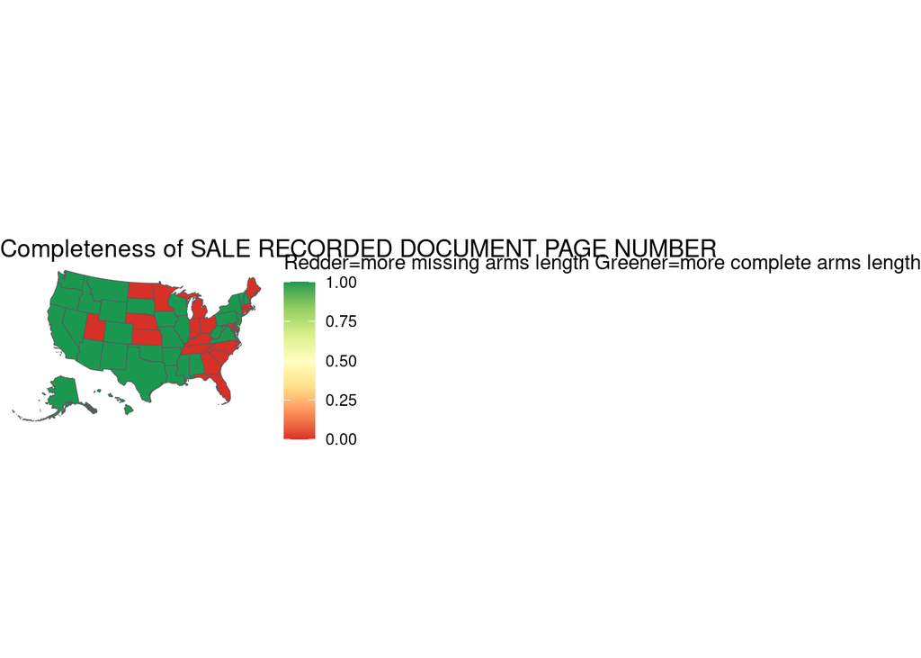

```r
library(readr)
library(DBI)
library(dbplyr)
library(dplyr)
library(duckdb)
library(duckplyr)
library(tidyr)
library(tidyselect)
library(tibble)
library(RSQLite)
library(stringr)
library(rlang)
library(styler)
library(sf)
library(ggplot2)
library(tigris)
#Data=read_csv("~/cl-validation/Output/ArmsLengthFipsData.csv")
#Data=Data |> filter(`Column`=="LAND USE CODE - STATIC")

#counties <- counties(cb = TRUE) |> shift_geometry()


#join_data <- left_join(
#  Data,
#  counties,
#  by = c(`FIPS.CODE` = "GEOID", `DEED.SITUS.STATE...STATIC` = "STUSPS"),
#  keep = TRUE
#)
#join_data=join_data|>filter(!is.na(NAME))


#ggplot() +
#  geom_sf(data = join_data, aes(fill = difference, geometry = geometry)) +
#scale_fill_distiller(palette = "RdYlGn", direction = 1) +
#  theme_minimal() +
#  labs(fill = "Redder=more missing arms length Greener=more complete arms length", title= "Completeness of COUNTY USE DESCRIPTION - STATIC ")+
 # theme_void()


#ggplot() +
# geom_sf(data = join_data, aes(fill = Binary, geometry = geometry)) +
#scale_fill_distiller(palette = "RdYlGn", direction = 1) +
# theme_minimal() +
#  labs(fill = "Red=Arms Length More Complete Green=Arms Length More Missing", title= "Completeness of COUNTY USE DESCRIPTION - STATIC ")+
 # theme_void()

#' Title
#'
#' @param fips Boolean TRUE=County Map plot FALSE= State Map plot
#' @param column String put in the column you want a map of
#' @param binary
#'
#' @return visual plot
#' @export
#'
#' @examples PlotMaker(TRUE,"SALE RECORDED DOCUMENT NUMBER",TRUE) Returns a county map plot for the column "SALE RECORDED DOCUMENT NUMBER" on a binary scale shows the comparison between arms length and non arms length
PlotMaker=function(fips,column,binary){
if(column=="SALE RECORDED DOCUMENT NUMBER"){
column="SALE RECORDED DOCUMENT NUMBER"
}

if(fips){
Data=read_csv("~/cl-validation/Output/ArmsLengthFipsData47-49.csv")
Data=Data |> filter(`Column`==column)
counties <- counties(cb = TRUE) |> shift_geometry()
join_data <- left_join(
  Data,
  counties,
  by = c(`FIPS.CODE` = "GEOID", `DEED.SITUS.STATE...STATIC` = "STUSPS"),
  keep = TRUE
)
join_data=join_data|>filter(!is.na(NAME))
if(binary){
TITLE=paste0("Completeness of ",column)
ggplot() +
  geom_sf(data = join_data, aes(fill = Binary, geometry = geometry)) +
scale_fill_distiller(palette = "RdYlGn", direction = 1) +
  theme_minimal() +
  labs(fill = "Redder=more missing arms length Greener=more complete arms length", title= TITLE)+
  theme_void()

}
else{
 TITLE=paste0("Completeness of ",column)
  ggplot() +
  geom_sf(data = join_data, aes(fill = difference, geometry = geometry)) +
scale_fill_distiller(palette = "RdYlGn", direction = 1) +
  theme_minimal() +
  labs(fill = "Redder=more missing arms length Greener=more complete arms length", title= TITLE)+
  theme_void()



}
  }
else{
Data=read_csv("~/cl-validation/Output/ArmsLengthData.csv")
Data=Data |> filter(`Column`==column)


JoinedData=left_join(Data, shift_geometry(states(cb=TRUE)),
                          by = c(`DEED.SITUS.STATE...STATIC` = "STUSPS"),
                          keep = TRUE)
if(binary){
TITLE=paste0("Completeness of ",column)
ggplot() +
  geom_sf(data = JoinedData, aes(fill = Binary, geometry = geometry)) +
scale_fill_distiller(palette = "RdYlGn", direction = 1) +
  theme_minimal() +
  labs(fill = "Redder=more missing arms length Greener=more complete arms length", title= TITLE)+
  theme_void()
}
else{
TITLE=paste0("Completeness of ",column)
ggplot() +
  geom_sf(data = JoinedData, aes(fill = difference, geometry = geometry)) +
scale_fill_distiller(palette = "RdYlGn", direction = 1) +
  theme_minimal() +
  labs(fill = "Redder=more missing arms length Greener=more complete arms length", title= TITLE)+
  theme_void()



}
}

}

PlotMaker(FALSE,"SALE RECORDED DOCUMENT PAGE NUMBER",TRUE)
```

```
## ──────────────────────────────────────────────────────── Delimiter: "," chr
## (2): DEED.SITUS.STATE...STATIC, Column dbl (3): ...1, difference, Binary
```

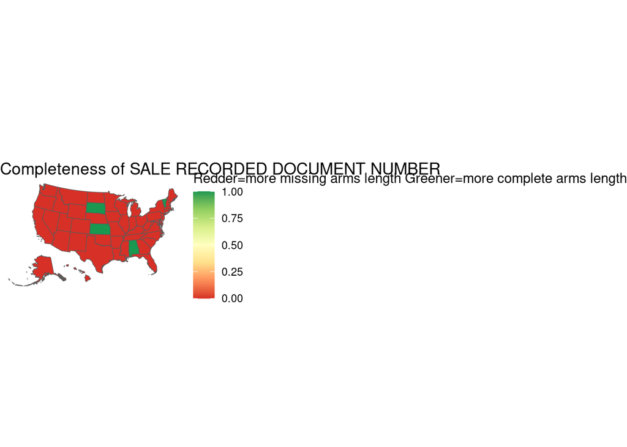

```r
PlotMaker(FALSE,"SALE RECORDED DOCUMENT NUMBER",TRUE)
```

```
## ──────────────────────────────────────────────────────── Delimiter: "," chr
## (3): DEED.SITUS.STATE...STATIC, Column, FIPS.CODE dbl (3): ...1, difference,
## Binary
```

[output not shown]

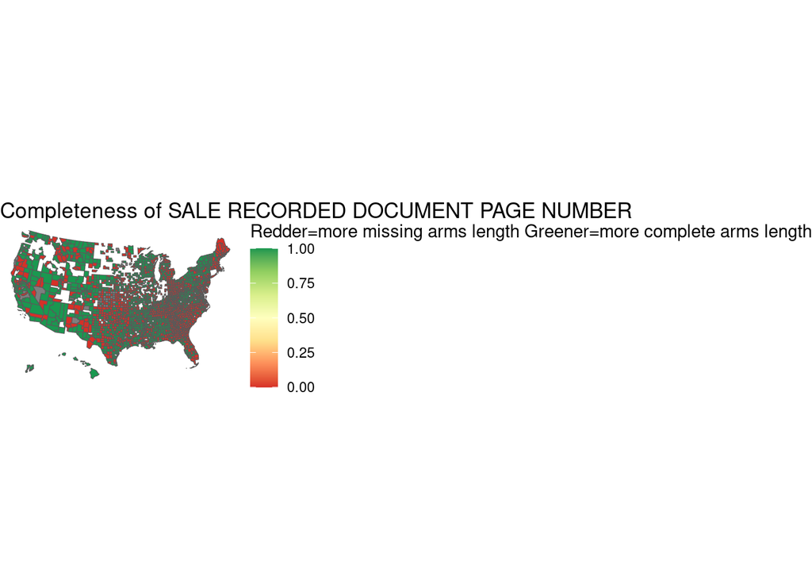

```r
PlotMaker(TRUE,"SALE RECORDED DOCUMENT PAGE NUMBER",TRUE)
```

```
## ──────────────────────────────────────────────────────── Delimiter: "," chr
## (3): DEED.SITUS.STATE...STATIC, Column, FIPS.CODE dbl (3): ...1, difference,
## Binary
```

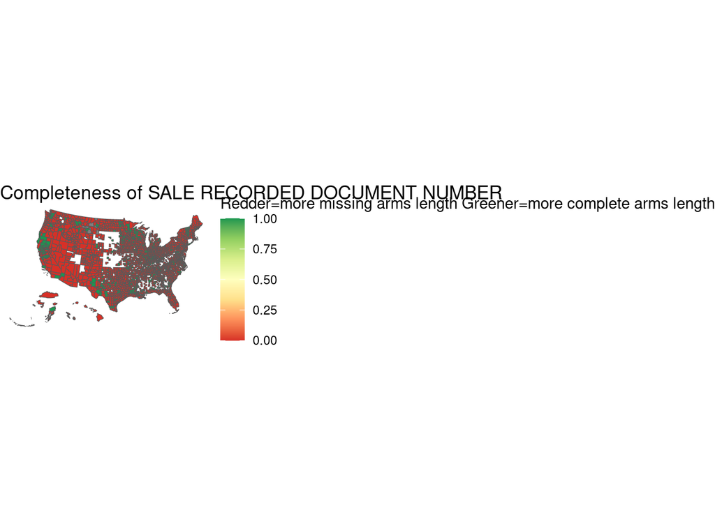

```r
PlotMaker(TRUE,"SALE RECORDED DOCUMENT NUMBER",TRUE)
```

#### How I did it previously without the function and the longer way of LollipopCreator()

```r
Data=read_csv("~/cl-validation/Output/ArmsLengthFull.csv")
```

```
## ──────────────────────────────────────────────────────── Delimiter: "," chr
## (2): DEED SITUS STATE - STATIC, Column dbl (3): ...1, difference, Difference
```

```r
Data=Data |> filter(`Column`=="COUNTY USE DESCRIPTION - STATIC")
JoinedData=left_join(Data, shift_geometry(states(cb=TRUE)),
                          by = c(`DEED SITUS STATE - STATIC` = "STUSPS"),
                          keep = TRUE)
```

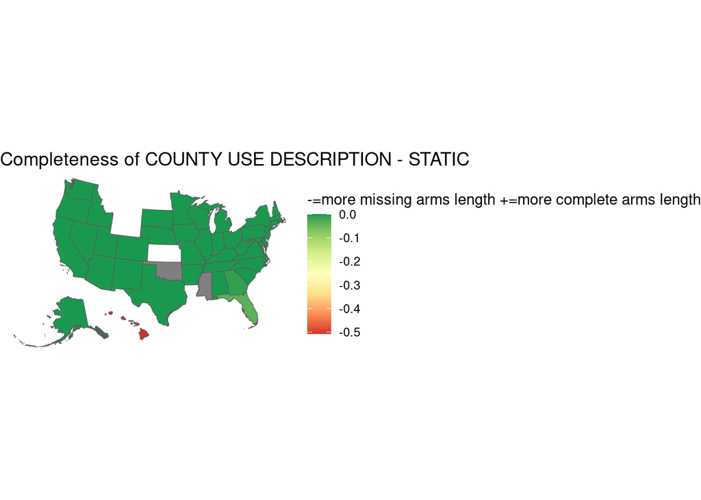

```r
ggplot() +
  geom_sf(data = JoinedData, aes(fill = difference, geometry = geometry)) +
scale_fill_distiller(palette = "RdYlGn", direction = 1) +
  theme_minimal() +
  labs(fill = "-=more missing arms length +=more complete arms length", title= "Completeness of COUNTY USE DESCRIPTION - STATIC ")+
  theme_void()
```

[figure not shown]

```r
ggplot() +
  geom_sf(data = JoinedData, aes(fill = Difference, geometry = geometry)) +
scale_fill_distiller(palette = "RdYlGn", direction = 1) +
  theme_minimal() +
  labs(fill = "Red=Arms Length More Complete Green=Arms Length More Missing", title= "Completeness of COUNTY USE DESCRIPTION - STATIC ")+
  theme_void()
```

```r
Data=read_csv("~/cl-validation/Output/ArmsLengthFull.csv")
```

```
## ──────────────────────────────────────────────────────── Delimiter: "," chr
## (2): DEED SITUS STATE - STATIC, Column dbl (3): ...1, difference, Difference
```

```r
Data=Data |> filter(`Column`=="SALE RECORDED DOCUMENT PAGE NUMBER")
JoinedData=left_join(Data, shift_geometry(states(cb=TRUE)),
                          by = c(`DEED SITUS STATE - STATIC` = "STUSPS"),
                          keep = TRUE)
```

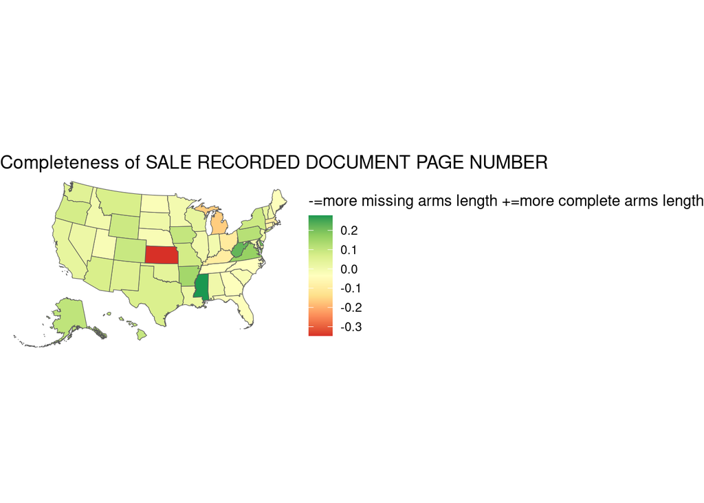

```r
ggplot() +
  geom_sf(data = JoinedData, aes(fill = difference, geometry = geometry)) +
scale_fill_distiller(palette = "RdYlGn", direction = 1) +
  theme_minimal() +
  labs(fill = "-=more missing arms length +=more complete arms length", title= "Completeness of SALE RECORDED DOCUMENT PAGE NUMBER ")+
  theme_void()
```

[figure not shown]

```r
ggplot() +
  geom_sf(data = JoinedData, aes(fill = Difference, geometry = geometry)) +
scale_fill_distiller(palette = "RdYlGn", direction = 1) +
  theme_minimal() +
  labs(fill = "Red=Arms Length More Complete Green=Arms Length More Missing", title= "Completeness of SALE RECORDED DOCUMENT PAGE NUMBER ")+
  theme_void()
```

```r
Data=read_csv("~/cl-validation/Output/ArmsLengthFull.csv")
```

```
## ──────────────────────────────────────────────────────── Delimiter: "," chr
## (2): DEED SITUS STATE - STATIC, Column dbl (3): ...1, difference, Difference
```

```r
Data=Data |> filter(`Column`=="SALE RECORDED DOCUMENT NUMBER")
JoinedData=left_join(Data, shift_geometry(states(cb=TRUE)),
                          by = c(`DEED SITUS STATE - STATIC` = "STUSPS"),
                          keep = TRUE)
print(Data)
```

```
## # A tibble: 51 × 5
##     ...1 `DEED SITUS STATE - STATIC` Column                difference Difference
##    <dbl> <chr>                       <chr>                      <dbl>      <dbl>
##  1  2286 WY                          SALE RECORDED DOCUME…    -0.154           0
##  2  2287 WV                          SALE RECORDED DOCUME…    -0.0916          0
##  3  2288 WI                          SALE RECORDED DOCUME…    -0.0411          0
##  4  2289 WA                          SALE RECORDED DOCUME…    -0.0583          0
##  5  2290 VT                          SALE RECORDED DOCUME…     0.0357          1
##  6  2291 VA                          SALE RECORDED DOCUME…    -0.285           0
##  7  2292 UT                          SALE RECORDED DOCUME…    -0.111           0
##  8  2293 TX                          SALE RECORDED DOCUME…    -0.185           0
##  9  2294 TN                          SALE RECORDED DOCUME…    -0.0897          0
## 10  2295 SD                          SALE RECORDED DOCUME…     0.0654          1
## # ℹ 41 more rows
```

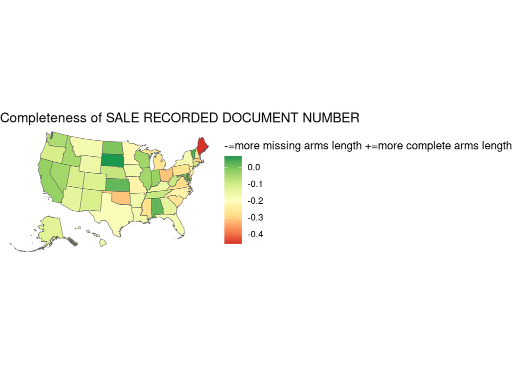

```r
ggplot() +
  geom_sf(data = JoinedData, aes(fill = difference, geometry = geometry)) +
scale_fill_distiller(palette = "RdYlGn", direction = 1) +
  theme_minimal() +
  labs(fill = "-=more missing arms length +=more complete arms length", title= "Completeness of SALE RECORDED DOCUMENT NUMBER ")+
  theme_void()
```

[figure not shown]

```r
ggplot() +
  geom_sf(data = JoinedData, aes(fill = Difference, geometry = geometry)) +
 scale_fill_distiller(palette = "RdYlGn", direction = 1) +
  theme_minimal() +
  labs(fill = "Red=Arms Length More Complete Green=Arms Length More Missing", title= "Completeness of SALE RECORDED DOCUMENT NUMBER ")+
  theme_void()
```

```r
Data=read_csv("~/cl-validation/Output/ArmsLengthFull.csv")
```

```
## ──────────────────────────────────────────────────────── Delimiter: "," chr
## (2): DEED SITUS STATE - STATIC, Column dbl (3): ...1, difference, Difference
```

```r
Data=Data |> filter(`Column`=="SALE RECORDED DOCUMENT BOOK NUMBER")
JoinedData=left_join(Data, shift_geometry(states(cb=TRUE)),
                          by = c(`DEED SITUS STATE - STATIC` = "STUSPS"),
                          keep = TRUE)
```

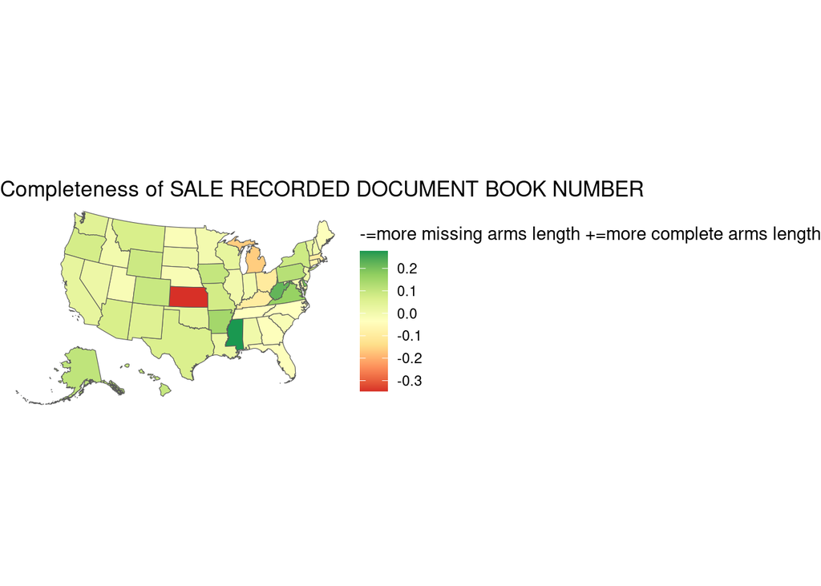

```r
ggplot() +
  geom_sf(data = JoinedData, aes(fill = difference, geometry = geometry)) +
scale_fill_distiller(palette = "RdYlGn", direction = 1) +
  theme_minimal() +
  labs(fill = "-=more missing arms length +=more complete arms length", title= "Completeness of SALE RECORDED DOCUMENT BOOK NUMBER ")+
  theme_void()
```

[figure not shown]

```r
ggplot() +
  geom_sf(data = JoinedData, aes(fill = Difference, geometry = geometry)) +
 scale_fill_distiller(palette = "RdYlGn", direction = 1) +
  theme_minimal() +
  labs(fill = "Red=Arms Length More Complete Green=Arms Length More Missing", title= "Completeness of SALE RECORDED DOCUMENT BOOK NUMBER ")+
  theme_void()
```

#### How I did it previously without the function and the longer way of LollipopCreator()

```r
ArmsLengthFullFips=read_csv("~/cl-validation/Output/ArmsLengthFullFips.csv")
```

```
## ──────────────────────────────────────────────────────── Delimiter: "," chr
## (3): DEED SITUS STATE - STATIC, FIPS CODE, Column dbl (3): ...1, difference,
## Difference
```

```r
ArmsLengthFullFips=ArmsLengthFullFips |> filter(`Column`=="SALE RECORDED DOCUMENT PAGE NUMBER")


counties <- counties(cb = TRUE) |> shift_geometry()
#print(counties)


join_data <- left_join(
  ArmsLengthFullFips,
  counties,
  by = c(`FIPS CODE` = "GEOID", `DEED SITUS STATE - STATIC` = "STUSPS"),
  keep = TRUE
)
join_data=join_data|>filter(!is.na(NAME))
print(join_data)
```

```
## # A tibble: 2,631 × 19
##     ...1 DEED SITUS STATE - S…¹ `FIPS CODE` Column difference Difference STATEFP
##    <dbl> <chr>                  <chr>       <chr>       <dbl>      <dbl> <chr>
##  1 32213 WY                     56043       SALE …   -0.238            0 56
##  2 32214 WY                     56041       SALE …   -0.00234          0 56
##  3 32215 WY                     56039       SALE …    0.143            1 56
##  4 32216 WY                     56037       SALE …    0.00327          1 56
##  5 32217 WY                     56035       SALE …    0.0112           1 56
##  6 32218 WY                     56033       SALE …    0.766            1 56
##  7 32219 WY                     56031       SALE …    0                0 56
##  8 32220 WY                     56023       SALE …   -0.0649           0 56
##  9 32221 WY                     56021       SALE …   -0.322            0 56
## 10 32222 WY                     56019       SALE …    0.731            1 56
## # ℹ 2,621 more rows
## # ℹ abbreviated name: ¹`DEED SITUS STATE - STATIC`
## # ℹ 12 more variables: COUNTYFP <chr>, COUNTYNS <chr>, AFFGEOID <chr>,
## #   GEOID <chr>, NAME <chr>, NAMELSAD <chr>, STUSPS <chr>, STATE_NAME <chr>,
## #   LSAD <chr>, ALAND <dbl>, AWATER <dbl>, geometry <MULTIPOLYGON [m]>
```

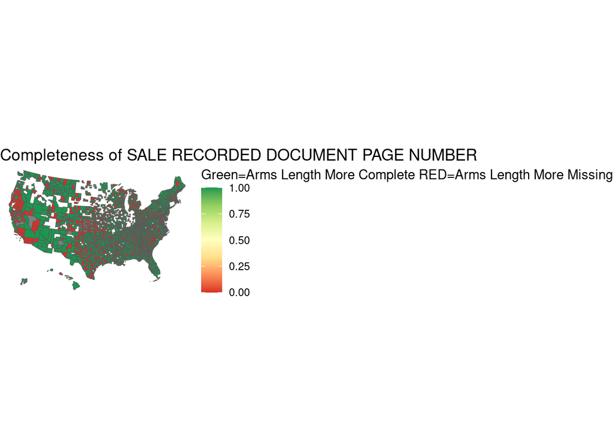

```r
ggplot()  +  geom_sf(data = join_data, aes(fill = Difference, geometry = geometry)) +
scale_fill_distiller(palette = "RdYlGn", direction = 1) +
  theme_minimal() +
  labs(fill = "Green=Arms Length More Complete RED=Arms Length More Missing", title= "Completeness of SALE RECORDED DOCUMENT PAGE NUMBER ")+
  theme_void()
```

```r
ArmsLengthFullFips=read_csv("~/cl-validation/Output/ArmsLengthFullFips.csv")
```

```
## ──────────────────────────────────────────────────────── Delimiter: "," chr
## (3): DEED SITUS STATE - STATIC, FIPS CODE, Column dbl (3): ...1, difference,
## Difference
```

```r
ArmsLengthFullFips=ArmsLengthFullFips |> filter(`Column`=="SALE RECORDED DOCUMENT NUMBER")


counties <- counties(cb = TRUE) |> shift_geometry()
```

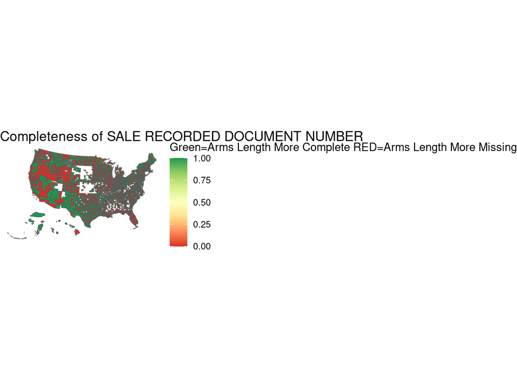

```r
#print(counties)


join_data <- left_join(
  ArmsLengthFullFips,
  counties,
  by = c(`FIPS CODE` = "GEOID", `DEED SITUS STATE - STATIC` = "STUSPS"),
  keep = TRUE
)
join_data=join_data|>filter(!is.na(NAME))


ggplot() +
  geom_sf(data = join_data, aes(fill = Difference, geometry = geometry)) +
scale_fill_distiller(palette = "RdYlGn", direction = 1) +
  theme_minimal() +
  labs(fill = "Green=Arms Length More Complete RED=Arms Length More Missing", title= "Completeness of SALE RECORDED DOCUMENT NUMBER")+
  theme_void()
```

### IMPORTANT For Quitclaim and Grant Deeds, with Arms Length Sales there is less missingness of SALE RECORDED DOCUMENT PAGE NUMBER; however that is not the case with “SALE RECORDED DOCUMENT NUMBER” True that there is less missingness with SALE RECORDED DOCUMENT NUMBER for these deeds

```r
con = dbConnect(duckdb(),"/projects/SHARKEY/corelogic_pu/CorelogicDeeds/2023Update/cl.db")

fullData = tbl(con, "deeds")
#pr=fullData  |>  filter(`DEED SITUS STATE - STATIC` %in% statenewabb)  |> filter(`FIPS CODE`=="32023") |> filter(!is.na(`SALE #RECORDED DOCUMENT PAGE NUMBER`))
#pr = fullData |> filter(!is.na(`APN (PARCEL NUMBER UNFORMATTED)`)) |> filter(is.na(`APN SEQUENCE NUMBER`)) |> summarise(n=n())
#pr = fullData |>  filter(`DEED SITUS STATE - STATIC` %in% statenewabb)
  ##|>  filter(`DEED SITUS STATE - STATIC` %in% statenewabb)
pr=fullData  |>  filter(`DEED SITUS STATE - STATIC` %in% statenewabb) |> filter(`DEED CATEGORY TYPE CODE`=="U" || `DEED CATEGORY TYPE CODE`=="Q" || `DEED CATEGORY TYPE CODE`=="G") |> group_by(`PRIMARY CATEGORY CODE`,`DEED CATEGORY TYPE CODE`,is.na(`SALE RECORDED DOCUMENT NUMBER`))|> summarise(n=n())  |> mutate("Proportion"=n/sum(n)) |> arrange(desc(`DEED CATEGORY TYPE CODE`),desc(`PRIMARY CATEGORY CODE`))
print(pr)
```

[output not shown]

```
## # Source:     SQL [?? x 5]
## # Database:   DuckDB v0.10.2 [jc9154@Linux 4.18.0-553.5.1.el8_10.x86_64:R 4.4.0//projects/SHARKEY/corelogic_pu/CorelogicDeeds/2023Update/cl.db]
## # Groups:     PRIMARY CATEGORY CODE, DEED CATEGORY TYPE CODE
## # Ordered by: desc(`DEED CATEGORY TYPE CODE`), desc(`PRIMARY CATEGORY CODE`)
##    `PRIMARY CATEGORY CODE` DEED CATEGORY TYPE CO…¹ is.na(\SALE RECORDED…²      n
##    <chr>                   <chr>                   <lgl>                   <dbl>
##  1 C                       U                       FALSE                  7.66e2
##  2 C                       U                       TRUE                   1.62e2
##  3 B                       U                       FALSE                  1.18e7
##  4 B                       U                       TRUE                   2.03e6
##  5 A                       U                       TRUE                   7.25e5
##  6 A                       U                       FALSE                  1.18e6
##  7 C                       Q                       FALSE                  4.77e6
##  8 C                       Q                       TRUE                   5.12e5
##  9 B                       Q                       FALSE                  2.96e7
## 10 B                       Q                       TRUE                   4.91e6
## # ℹ more rows
## # ℹ abbreviated names: ¹`DEED CATEGORY TYPE CODE`,
## #   ²`is.na(\`SALE RECORDED DOCUMENT NUMBER\`)`
## # ℹ 1 more variable: Proportion <dbl>
```

```r
pr=fullData  |>  filter(`DEED SITUS STATE - STATIC` %in% statenewabb) |> filter(`DEED CATEGORY TYPE CODE`=="U" || `DEED CATEGORY TYPE CODE`=="Q" || `DEED CATEGORY TYPE CODE`=="G") |> group_by(`PRIMARY CATEGORY CODE`,`DEED CATEGORY TYPE CODE`,is.na(`SALE RECORDED DOCUMENT PAGE NUMBER`))|> summarise(n=n())  |> mutate("Proportion"=n/sum(n)) |> arrange(desc(`DEED CATEGORY TYPE CODE`),desc(`PRIMARY CATEGORY CODE`))
print(pr)
```

[output not shown]

```
## # Source:     SQL [?? x 5]
## # Database:   DuckDB v0.10.2 [jc9154@Linux 4.18.0-553.5.1.el8_10.x86_64:R 4.4.0//projects/SHARKEY/corelogic_pu/CorelogicDeeds/2023Update/cl.db]
## # Groups:     PRIMARY CATEGORY CODE, DEED CATEGORY TYPE CODE
## # Ordered by: desc(`DEED CATEGORY TYPE CODE`), desc(`PRIMARY CATEGORY CODE`)
##    `PRIMARY CATEGORY CODE` DEED CATEGORY TYPE CO…¹ is.na(\SALE RECORDED…²      n
##    <chr>                   <chr>                   <lgl>                   <dbl>
##  1 C                       U                       TRUE                   4.67e2
##  2 C                       U                       FALSE                  4.61e2
##  3 B                       U                       TRUE                   7.32e6
##  4 B                       U                       FALSE                  6.51e6
##  5 A                       U                       FALSE                  7.48e5
##  6 A                       U                       TRUE                   1.16e6
##  7 C                       Q                       FALSE                  1.82e6
##  8 C                       Q                       TRUE                   3.46e6
##  9 B                       Q                       TRUE                   1.93e7
## 10 B                       Q                       FALSE                  1.51e7
## # ℹ more rows
## # ℹ abbreviated names: ¹`DEED CATEGORY TYPE CODE`,
## #   ²`is.na(\`SALE RECORDED DOCUMENT PAGE NUMBER\`)`
## # ℹ 1 more variable: Proportion <dbl>
```

```r
#pr=fullData  |>  filter(`DEED SITUS STATE - STATIC` %in% statenewabb) |> filter(`DEED CATEGORY TYPE CODE`=="U")|>group_by(is.na(`SALE RECORDED DOCUMENT PAGE NUMBER`))|> summarise(n=n())
#print(pr)

dbDisconnect(con)
```